# Risk Factor Analysis

## Outcome Variable

**Outcome Variable:** pers_wast

## Predictor Variables

**Intervention Variable:** nrooms

**Adjustment Set:**

- arm
- sex
- W_mage
- meducyrs
- feducyrs
- hhwealth_quart
- hfoodsec
- W_mhtcm
- W_mwtkg
- W_mbmi
- W_nchldlt5
- W_parity
- impfloor
- impsan
- safeh20
- delta_W_mage
- delta_meducyrs
- delta_feducyrs
- delta_hhwealth_quart
- delta_hfoodsec
- delta_W_mhtcm
- delta_W_mwtkg
- delta_W_mbmi
- delta_W_nchldlt5
- delta_W_parity
- delta_impfloor
- delta_impsan
- delta_safeh20

## Stratifying Variables

The analysis was stratified on these variable(s):

- agecat
- studyid
- country

## Data Summary

| agecat | studyid | country | nrooms | pers_wast | n_cell | n |
| --- | --- | --- | --- | --- | --- | --- |
| 0-24 months | ki0047075b-MAL-ED | BANGLADESH | 4+ | 0 | 9 | 242 |
| 0-24 months | ki0047075b-MAL-ED | BANGLADESH | 4+ | 1 | 3 | 242 |
| 0-24 months | ki0047075b-MAL-ED | BANGLADESH | 1 | 0 | 145 | 242 |
| 0-24 months | ki0047075b-MAL-ED | BANGLADESH | 1 | 1 | 7 | 242 |
| 0-24 months | ki0047075b-MAL-ED | BANGLADESH | 2 | 0 | 48 | 242 |
| 0-24 months | ki0047075b-MAL-ED | BANGLADESH | 2 | 1 | 2 | 242 |
| 0-24 months | ki0047075b-MAL-ED | BANGLADESH | 3 | 0 | 27 | 242 |
| 0-24 months | ki0047075b-MAL-ED | BANGLADESH | 3 | 1 | 1 | 242 |
| 0-24 months | ki0047075b-MAL-ED | BRAZIL | 4+ | 0 | 125 | 210 |
| 0-24 months | ki0047075b-MAL-ED | BRAZIL | 4+ | 1 | 2 | 210 |
| 0-24 months | ki0047075b-MAL-ED | BRAZIL | 1 | 0 | 4 | 210 |
| 0-24 months | ki0047075b-MAL-ED | BRAZIL | 1 | 1 | 0 | 210 |
| 0-24 months | ki0047075b-MAL-ED | BRAZIL | 2 | 0 | 20 | 210 |
| 0-24 months | ki0047075b-MAL-ED | BRAZIL | 2 | 1 | 0 | 210 |
| 0-24 months | ki0047075b-MAL-ED | BRAZIL | 3 | 0 | 59 | 210 |
| 0-24 months | ki0047075b-MAL-ED | BRAZIL | 3 | 1 | 0 | 210 |
| 0-24 months | ki0047075b-MAL-ED | INDIA | 4+ | 0 | 23 | 235 |
| 0-24 months | ki0047075b-MAL-ED | INDIA | 4+ | 1 | 2 | 235 |
| 0-24 months | ki0047075b-MAL-ED | INDIA | 1 | 0 | 78 | 235 |
| 0-24 months | ki0047075b-MAL-ED | INDIA | 1 | 1 | 6 | 235 |
| 0-24 months | ki0047075b-MAL-ED | INDIA | 2 | 0 | 72 | 235 |
| 0-24 months | ki0047075b-MAL-ED | INDIA | 2 | 1 | 6 | 235 |
| 0-24 months | ki0047075b-MAL-ED | INDIA | 3 | 0 | 42 | 235 |
| 0-24 months | ki0047075b-MAL-ED | INDIA | 3 | 1 | 6 | 235 |
| 0-24 months | ki0047075b-MAL-ED | NEPAL | 4+ | 0 | 129 | 236 |
| 0-24 months | ki0047075b-MAL-ED | NEPAL | 4+ | 1 | 2 | 236 |
| 0-24 months | ki0047075b-MAL-ED | NEPAL | 1 | 0 | 51 | 236 |
| 0-24 months | ki0047075b-MAL-ED | NEPAL | 1 | 1 | 1 | 236 |
| 0-24 months | ki0047075b-MAL-ED | NEPAL | 2 | 0 | 31 | 236 |
| 0-24 months | ki0047075b-MAL-ED | NEPAL | 2 | 1 | 0 | 236 |

[output cut: 338 more lines]

The following strata were considered:

- agecat: 0-24 months, studyid: ki0047075b-MAL-ED, country: BANGLADESH
- agecat: 0-24 months, studyid: ki0047075b-MAL-ED, country: BRAZIL
- agecat: 0-24 months, studyid: ki0047075b-MAL-ED, country: INDIA
- agecat: 0-24 months, studyid: ki0047075b-MAL-ED, country: NEPAL
- agecat: 0-24 months, studyid: ki0047075b-MAL-ED, country: PERU
- agecat: 0-24 months, studyid: ki0047075b-MAL-ED, country: SOUTH AFRICA
- agecat: 0-24 months, studyid: ki0047075b-MAL-ED, country: TANZANIA, UNITED REPUBLIC OF
- agecat: 0-24 months, studyid: ki1000108-CMC-V-BCS-2002, country: INDIA
- agecat: 0-24 months, studyid: ki1000108-IRC, country: INDIA
- agecat: 0-24 months, studyid: ki1017093b-PROVIDE, country: BANGLADESH
- agecat: 0-24 months, studyid: ki1017093c-NIH-Crypto, country: BANGLADESH
- agecat: 0-24 months, studyid: ki1113344-GMS-Nepal, country: NEPAL
- agecat: 0-24 months, studyid: ki1114097-CONTENT, country: PERU
- agecat: 0-24 months, studyid: ki1135781-COHORTS, country: INDIA
- agecat: 0-24 months, studyid: kiGH5241-JiVitA-3, country: BANGLADESH
- agecat: 0-24 months, studyid: kiGH5241-JiVitA-4, country: BANGLADESH
- agecat: 0-6 months, studyid: ki0047075b-MAL-ED, country: BANGLADESH
- agecat: 0-6 months, studyid: ki0047075b-MAL-ED, country: BRAZIL
- agecat: 0-6 months, studyid: ki0047075b-MAL-ED, country: INDIA
- agecat: 0-6 months, studyid: ki0047075b-MAL-ED, country: NEPAL
- agecat: 0-6 months, studyid: ki0047075b-MAL-ED, country: PERU
- agecat: 0-6 months, studyid: ki0047075b-MAL-ED, country: SOUTH AFRICA
- agecat: 0-6 months, studyid: ki0047075b-MAL-ED, country: TANZANIA, UNITED REPUBLIC OF
- agecat: 0-6 months, studyid: ki1000108-CMC-V-BCS-2002, country: INDIA
- agecat: 0-6 months, studyid: ki1000108-IRC, country: INDIA
- agecat: 0-6 months, studyid: ki1017093b-PROVIDE, country: BANGLADESH
- agecat: 0-6 months, studyid: ki1017093c-NIH-Crypto, country: BANGLADESH
- agecat: 0-6 months, studyid: ki1113344-GMS-Nepal, country: NEPAL
- agecat: 0-6 months, studyid: ki1114097-CONTENT, country: PERU
- agecat: 0-6 months, studyid: kiGH5241-JiVitA-3, country: BANGLADESH
- agecat: 6-24 months, studyid: ki0047075b-MAL-ED, country: BANGLADESH
- agecat: 6-24 months, studyid: ki0047075b-MAL-ED, country: BRAZIL
- agecat: 6-24 months, studyid: ki0047075b-MAL-ED, country: INDIA
- agecat: 6-24 months, studyid: ki0047075b-MAL-ED, country: NEPAL
- agecat: 6-24 months, studyid: ki0047075b-MAL-ED, country: PERU
- agecat: 6-24 months, studyid: ki0047075b-MAL-ED, country: SOUTH AFRICA
- agecat: 6-24 months, studyid: ki0047075b-MAL-ED, country: TANZANIA, UNITED REPUBLIC OF
- agecat: 6-24 months, studyid: ki1000108-CMC-V-BCS-2002, country: INDIA
- agecat: 6-24 months, studyid: ki1000108-IRC, country: INDIA
- agecat: 6-24 months, studyid: ki1017093b-PROVIDE, country: BANGLADESH
- agecat: 6-24 months, studyid: ki1017093c-NIH-Crypto, country: BANGLADESH
- agecat: 6-24 months, studyid: ki1113344-GMS-Nepal, country: NEPAL
- agecat: 6-24 months, studyid: ki1114097-CONTENT, country: PERU
- agecat: 6-24 months, studyid: ki1135781-COHORTS, country: INDIA
- agecat: 6-24 months, studyid: kiGH5241-JiVitA-3, country: BANGLADESH
- agecat: 6-24 months, studyid: kiGH5241-JiVitA-4, country: BANGLADESH

### Dropped Strata

Some strata were dropped due to rare outcomes:

- agecat: 0-24 months, studyid: ki0047075b-MAL-ED, country: BANGLADESH
- agecat: 0-24 months, studyid: ki0047075b-MAL-ED, country: BRAZIL
- agecat: 0-24 months, studyid: ki0047075b-MAL-ED, country: INDIA
- agecat: 0-24 months, studyid: ki0047075b-MAL-ED, country: NEPAL
- agecat: 0-24 months, studyid: ki0047075b-MAL-ED, country: PERU
- agecat: 0-24 months, studyid: ki0047075b-MAL-ED, country: SOUTH AFRICA
- agecat: 0-24 months, studyid: ki0047075b-MAL-ED, country: TANZANIA, UNITED REPUBLIC OF
- agecat: 0-24 months, studyid: ki1000108-CMC-V-BCS-2002, country: INDIA
- agecat: 0-24 months, studyid: ki1000108-IRC, country: INDIA
- agecat: 0-24 months, studyid: ki1017093b-PROVIDE, country: BANGLADESH
- agecat: 0-24 months, studyid: ki1017093c-NIH-Crypto, country: BANGLADESH
- agecat: 0-24 months, studyid: ki1114097-CONTENT, country: PERU
- agecat: 0-24 months, studyid: ki1135781-COHORTS, country: INDIA
- agecat: 0-6 months, studyid: ki0047075b-MAL-ED, country: BANGLADESH
- agecat: 0-6 months, studyid: ki0047075b-MAL-ED, country: BRAZIL
- agecat: 0-6 months, studyid: ki0047075b-MAL-ED, country: INDIA
- agecat: 0-6 months, studyid: ki0047075b-MAL-ED, country: NEPAL
- agecat: 0-6 months, studyid: ki0047075b-MAL-ED, country: PERU
- agecat: 0-6 months, studyid: ki0047075b-MAL-ED, country: SOUTH AFRICA
- agecat: 0-6 months, studyid: ki0047075b-MAL-ED, country: TANZANIA, UNITED REPUBLIC OF
- agecat: 0-6 months, studyid: ki1000108-CMC-V-BCS-2002, country: INDIA
- agecat: 0-6 months, studyid: ki1000108-IRC, country: INDIA
- agecat: 0-6 months, studyid: ki1017093b-PROVIDE, country: BANGLADESH
- agecat: 0-6 months, studyid: ki1017093c-NIH-Crypto, country: BANGLADESH
- agecat: 0-6 months, studyid: ki1114097-CONTENT, country: PERU
- agecat: 0-6 months, studyid: kiGH5241-JiVitA-3, country: BANGLADESH
- agecat: 6-24 months, studyid: ki0047075b-MAL-ED, country: BANGLADESH
- agecat: 6-24 months, studyid: ki0047075b-MAL-ED, country: BRAZIL
- agecat: 6-24 months, studyid: ki0047075b-MAL-ED, country: INDIA
- agecat: 6-24 months, studyid: ki0047075b-MAL-ED, country: NEPAL
- agecat: 6-24 months, studyid: ki0047075b-MAL-ED, country: PERU
- agecat: 6-24 months, studyid: ki0047075b-MAL-ED, country: SOUTH AFRICA
- agecat: 6-24 months, studyid: ki0047075b-MAL-ED, country: TANZANIA, UNITED REPUBLIC OF
- agecat: 6-24 months, studyid: ki1000108-CMC-V-BCS-2002, country: INDIA
- agecat: 6-24 months, studyid: ki1000108-IRC, country: INDIA
- agecat: 6-24 months, studyid: ki1017093b-PROVIDE, country: BANGLADESH
- agecat: 6-24 months, studyid: ki1017093c-NIH-Crypto, country: BANGLADESH
- agecat: 6-24 months, studyid: ki1114097-CONTENT, country: PERU
- agecat: 6-24 months, studyid: ki1135781-COHORTS, country: INDIA

## Methods Detail

We’re interested in the causal parameters $E[Y_a]$ for all values of $a \in \mathcal{A}$. These parameters represent the mean outcome if, possibly contrary to fact, we intervened to set all units to have $A=a$. Under the randomization and positivity assumptions, these are identified by the statistical parameters $\psi_a=E_W[E_{Y|A,W}(Y|A=a,W)]$. In addition, we’re interested in the mean of $Y$, $E[Y]$ under no intervention (the observed mean). We will estimate these parameters by using SuperLearner to fit the relevant likelihood factors – $E_{Y|A,W}(Y|A=a,W)$ and $p(A=a|W)$, and then updating our likelihood fit using a joint TMLE.

For unadjusted analyses ($W=\{\}$), initial likelihoods were estimated using Lrnr_glm to estimate the simple $E(Y|A)$ and Lrnr_mean to estimate $p(A)$. For adjusted analyses, a small library containing Lrnr_glmnet, Lrnr_xgboost, and Lrnr_mean was used.

Having estimated these parameters, we will then use the delta method to estimate relative risks and attributable risks relative to a prespecified baseline level of $A$.

# Results Detail

## Results Plots

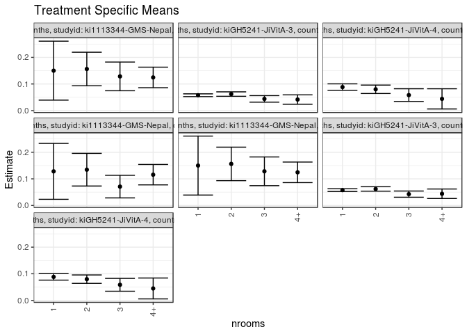

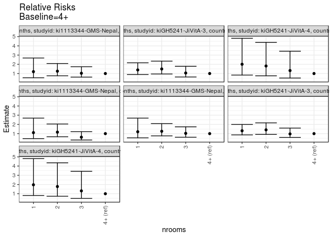

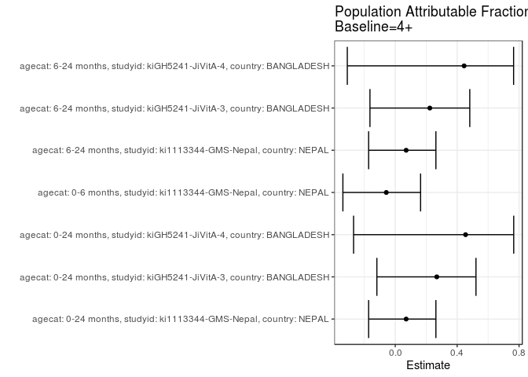

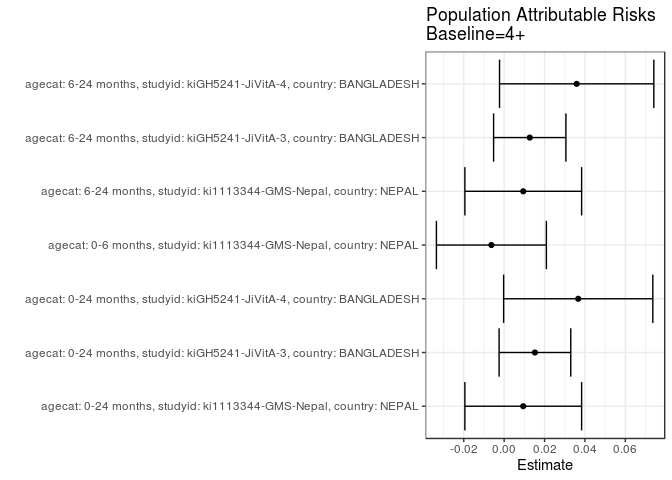

## Results Table

### Parameter: TSM

| agecat | studyid | country | intervention_level | baseline_level | estimate | ci_lower | ci_upper |
| --- | --- | --- | --- | --- | --- | --- | --- |
| 0-24 months | ki1113344-GMS-Nepal | NEPAL | 4+ | NA | 0.1245552 | 0.0859136 | 0.1631967 |
| 0-24 months | ki1113344-GMS-Nepal | NEPAL | 1 | NA | 0.1500000 | 0.0392517 | 0.2607483 |
| 0-24 months | ki1113344-GMS-Nepal | NEPAL | 2 | NA | 0.1562500 | 0.0932959 | 0.2192041 |
| 0-24 months | ki1113344-GMS-Nepal | NEPAL | 3 | NA | 0.1283784 | 0.0744408 | 0.1823159 |
| 0-24 months | kiGH5241-JiVitA-3 | BANGLADESH | 4+ | NA | 0.0415006 | 0.0238435 | 0.0591577 |
| 0-24 months | kiGH5241-JiVitA-3 | BANGLADESH | 1 | NA | 0.0576874 | 0.0524887 | 0.0628861 |
| 0-24 months | kiGH5241-JiVitA-3 | BANGLADESH | 2 | NA | 0.0620350 | 0.0536866 | 0.0703834 |
| 0-24 months | kiGH5241-JiVitA-3 | BANGLADESH | 3 | NA | 0.0438649 | 0.0315810 | 0.0561488 |
| 0-24 months | kiGH5241-JiVitA-4 | BANGLADESH | 4+ | NA | 0.0440180 | 0.0060286 | 0.0820075 |
| 0-24 months | kiGH5241-JiVitA-4 | BANGLADESH | 1 | NA | 0.0882871 | 0.0761698 | 0.1004043 |
| 0-24 months | kiGH5241-JiVitA-4 | BANGLADESH | 2 | NA | 0.0799730 | 0.0641522 | 0.0957937 |
| 0-24 months | kiGH5241-JiVitA-4 | BANGLADESH | 3 | NA | 0.0581744 | 0.0343268 | 0.0820220 |
| 0-6 months | ki1113344-GMS-Nepal | NEPAL | 4+ | NA | 0.1156716 | 0.0773465 | 0.1539968 |
| 0-6 months | ki1113344-GMS-Nepal | NEPAL | 1 | NA | 0.1282051 | 0.0231883 | 0.2332220 |
| 0-6 months | ki1113344-GMS-Nepal | NEPAL | 2 | NA | 0.1344538 | 0.0731073 | 0.1958002 |
| 0-6 months | ki1113344-GMS-Nepal | NEPAL | 3 | NA | 0.0709220 | 0.0285149 | 0.1133291 |
| 6-24 months | ki1113344-GMS-Nepal | NEPAL | 4+ | NA | 0.1245552 | 0.0859136 | 0.1631967 |
| 6-24 months | ki1113344-GMS-Nepal | NEPAL | 1 | NA | 0.1500000 | 0.0392517 | 0.2607483 |
| 6-24 months | ki1113344-GMS-Nepal | NEPAL | 2 | NA | 0.1562500 | 0.0932959 | 0.2192041 |
| 6-24 months | ki1113344-GMS-Nepal | NEPAL | 3 | NA | 0.1283784 | 0.0744408 | 0.1823159 |
| 6-24 months | kiGH5241-JiVitA-3 | BANGLADESH | 4+ | NA | 0.0440577 | 0.0262197 | 0.0618956 |
| 6-24 months | kiGH5241-JiVitA-3 | BANGLADESH | 1 | NA | 0.0577738 | 0.0525690 | 0.0629785 |
| 6-24 months | kiGH5241-JiVitA-3 | BANGLADESH | 2 | NA | 0.0620238 | 0.0536388 | 0.0704088 |
| 6-24 months | kiGH5241-JiVitA-3 | BANGLADESH | 3 | NA | 0.0426693 | 0.0310304 | 0.0543083 |
| 6-24 months | kiGH5241-JiVitA-4 | BANGLADESH | 4+ | NA | 0.0447895 | 0.0054958 | 0.0840832 |
| 6-24 months | kiGH5241-JiVitA-4 | BANGLADESH | 1 | NA | 0.0882427 | 0.0761175 | 0.1003680 |
| 6-24 months | kiGH5241-JiVitA-4 | BANGLADESH | 2 | NA | 0.0797396 | 0.0639013 | 0.0955779 |
| 6-24 months | kiGH5241-JiVitA-4 | BANGLADESH | 3 | NA | 0.0586010 | 0.0345286 | 0.0826734 |

### Parameter: E(Y)

| agecat | studyid | country | intervention_level | baseline_level | estimate | ci_lower | ci_upper |
| --- | --- | --- | --- | --- | --- | --- | --- |
| 0-24 months | ki1113344-GMS-Nepal | NEPAL | NA | NA | 0.1340034 | 0.1066544 | 0.1613523 |
| 0-24 months | kiGH5241-JiVitA-3 | BANGLADESH | NA | NA | 0.0567340 | 0.0526176 | 0.0608504 |
| 0-24 months | kiGH5241-JiVitA-4 | BANGLADESH | NA | NA | 0.0806971 | 0.0720842 | 0.0893100 |
| 0-6 months | ki1113344-GMS-Nepal | NEPAL | NA | NA | 0.1093474 | 0.0836377 | 0.1350572 |
| 6-24 months | ki1113344-GMS-Nepal | NEPAL | NA | NA | 0.1340034 | 0.1066544 | 0.1613523 |
| 6-24 months | kiGH5241-JiVitA-3 | BANGLADESH | NA | NA | 0.0567340 | 0.0526176 | 0.0608504 |
| 6-24 months | kiGH5241-JiVitA-4 | BANGLADESH | NA | NA | 0.0806971 | 0.0720842 | 0.0893100 |

### Parameter: RR

| agecat | studyid | country | intervention_level | baseline_level | estimate | ci_lower | ci_upper |
| --- | --- | --- | --- | --- | --- | --- | --- |
| 0-24 months | ki1113344-GMS-Nepal | NEPAL | 4+ | 4+ | 1.0000000 | 1.0000000 | 1.000000 |
| 0-24 months | ki1113344-GMS-Nepal | NEPAL | 1 | 4+ | 1.2042857 | 0.5406588 | 2.682476 |
| 0-24 months | ki1113344-GMS-Nepal | NEPAL | 2 | 4+ | 1.2544643 | 0.7544253 | 2.085933 |
| 0-24 months | ki1113344-GMS-Nepal | NEPAL | 3 | 4+ | 1.0306950 | 0.6113785 | 1.737602 |
| 0-24 months | kiGH5241-JiVitA-3 | BANGLADESH | 4+ | 4+ | 1.0000000 | 1.0000000 | 1.000000 |
| 0-24 months | kiGH5241-JiVitA-3 | BANGLADESH | 1 | 4+ | 1.3900384 | 0.8942390 | 2.160728 |
| 0-24 months | kiGH5241-JiVitA-3 | BANGLADESH | 2 | 4+ | 1.4947996 | 0.9518722 | 2.347401 |
| 0-24 months | kiGH5241-JiVitA-3 | BANGLADESH | 3 | 4+ | 1.0569710 | 0.6260591 | 1.784477 |
| 0-24 months | kiGH5241-JiVitA-4 | BANGLADESH | 4+ | 4+ | 1.0000000 | 1.0000000 | 1.000000 |
| 0-24 months | kiGH5241-JiVitA-4 | BANGLADESH | 1 | 4+ | 2.0057025 | 0.8339994 | 4.823556 |
| 0-24 months | kiGH5241-JiVitA-4 | BANGLADESH | 2 | 4+ | 1.8168236 | 0.7536199 | 4.379990 |
| 0-24 months | kiGH5241-JiVitA-4 | BANGLADESH | 3 | 4+ | 1.3216044 | 0.5102077 | 3.423387 |
| 0-6 months | ki1113344-GMS-Nepal | NEPAL | 4+ | 4+ | 1.0000000 | 1.0000000 | 1.000000 |
| 0-6 months | ki1113344-GMS-Nepal | NEPAL | 1 | 4+ | 1.1083540 | 0.4580729 | 2.681775 |
| 0-6 months | ki1113344-GMS-Nepal | NEPAL | 2 | 4+ | 1.1623746 | 0.6613911 | 2.042838 |
| 0-6 months | ki1113344-GMS-Nepal | NEPAL | 3 | 4+ | 0.6131320 | 0.3095066 | 1.214613 |
| 6-24 months | ki1113344-GMS-Nepal | NEPAL | 4+ | 4+ | 1.0000000 | 1.0000000 | 1.000000 |
| 6-24 months | ki1113344-GMS-Nepal | NEPAL | 1 | 4+ | 1.2042857 | 0.5406588 | 2.682476 |
| 6-24 months | ki1113344-GMS-Nepal | NEPAL | 2 | 4+ | 1.2544643 | 0.7544253 | 2.085933 |
| 6-24 months | ki1113344-GMS-Nepal | NEPAL | 3 | 4+ | 1.0306950 | 0.6113785 | 1.737602 |
| 6-24 months | kiGH5241-JiVitA-3 | BANGLADESH | 4+ | 4+ | 1.0000000 | 1.0000000 | 1.000000 |
| 6-24 months | kiGH5241-JiVitA-3 | BANGLADESH | 1 | 4+ | 1.3113217 | 0.8609517 | 1.997283 |
| 6-24 months | kiGH5241-JiVitA-3 | BANGLADESH | 2 | 4+ | 1.4077871 | 0.9142268 | 2.167804 |
| 6-24 months | kiGH5241-JiVitA-3 | BANGLADESH | 3 | 4+ | 0.9684889 | 0.5861991 | 1.600089 |
| 6-24 months | kiGH5241-JiVitA-4 | BANGLADESH | 4+ | 4+ | 1.0000000 | 1.0000000 | 1.000000 |
| 6-24 months | kiGH5241-JiVitA-4 | BANGLADESH | 1 | 4+ | 1.9701667 | 0.8078668 | 4.804699 |
| 6-24 months | kiGH5241-JiVitA-4 | BANGLADESH | 2 | 4+ | 1.7803198 | 0.7279992 | 4.353767 |
| 6-24 months | kiGH5241-JiVitA-4 | BANGLADESH | 3 | 4+ | 1.3083655 | 0.4986814 | 3.432693 |

### Parameter: PAR

| agecat | studyid | country | intervention_level | baseline_level | estimate | ci_lower | ci_upper |
| --- | --- | --- | --- | --- | --- | --- | --- |
| 0-24 months | ki1113344-GMS-Nepal | NEPAL | 4+ | NA | 0.0094482 | -0.0194569 | 0.0383533 |
| 0-24 months | kiGH5241-JiVitA-3 | BANGLADESH | 4+ | NA | 0.0152334 | -0.0025124 | 0.0329793 |
| 0-24 months | kiGH5241-JiVitA-4 | BANGLADESH | 4+ | NA | 0.0366791 | -0.0002567 | 0.0736148 |
| 0-6 months | ki1113344-GMS-Nepal | NEPAL | 4+ | NA | -0.0063242 | -0.0335510 | 0.0209026 |
| 6-24 months | ki1113344-GMS-Nepal | NEPAL | 4+ | NA | 0.0094482 | -0.0194569 | 0.0383533 |
| 6-24 months | kiGH5241-JiVitA-3 | BANGLADESH | 4+ | NA | 0.0126763 | -0.0052279 | 0.0305806 |
| 6-24 months | kiGH5241-JiVitA-4 | BANGLADESH | 4+ | NA | 0.0359076 | -0.0022935 | 0.0741087 |

### Parameter: PAF

| agecat | studyid | country | intervention_level | baseline_level | estimate | ci_lower | ci_upper |
| --- | --- | --- | --- | --- | --- | --- | --- |
| 0-24 months | ki1113344-GMS-Nepal | NEPAL | 4+ | NA | 0.0705071 | -0.1718485 | 0.2627400 |
| 0-24 months | kiGH5241-JiVitA-3 | BANGLADESH | 4+ | NA | 0.2685064 | -0.1186207 | 0.5216583 |
| 0-24 months | kiGH5241-JiVitA-4 | BANGLADESH | 4+ | NA | 0.4545278 | -0.2691714 | 0.7655637 |
| 0-6 months | ki1113344-GMS-Nepal | NEPAL | 4+ | NA | -0.0578358 | -0.3382265 | 0.1638063 |
| 6-24 months | ki1113344-GMS-Nepal | NEPAL | 4+ | NA | 0.0705071 | -0.1718485 | 0.2627400 |
| 6-24 months | kiGH5241-JiVitA-3 | BANGLADESH | 4+ | NA | 0.2234347 | -0.1633492 | 0.4816229 |
| 6-24 months | kiGH5241-JiVitA-4 | BANGLADESH | 4+ | NA | 0.4449679 | -0.3097171 | 0.7647884 |